# Introduction to linear regression

Data Science for Biologists, Spring 2020

Paige Richards

## Instructions

Standard grading criteria apply, except there is no “answer style” - just write out answers normally! Note the following:

- $\alpha = 0.05$
- When adding regression lines as plot subtitles, don’t worry about writing $\epsilon$
- Do not remove insignificant predictors from your regression line formula when reporting it (this is just a question I get a lot)

For this assignment, you will examine how various predictors may explain variation in *respiratory rate.*

```r
# rowan trees, no relation :)
rowan <- read_csv("https://raw.githubusercontent.com/sjspielman/datascience_for_biologists/master/data/rowan_trees.csv")
dplyr::glimpse(rowan)
```

```
## Observations: 300
## Variables: 5
## $ species          <chr> "microphylla", "microphylla", "microphylla", "microp…
## $ altitude         <dbl> 457, 644, 497, 412, 460, 467, 394, 474, 475, 397, 51…
## $ respiratory_rate <dbl> 0.266, 0.272, 0.231, 0.108, 0.216, 0.291, 0.244, 0.0…
## $ leaf_len         <dbl> 8.7, 9.5, 7.9, 9.5, 10.1, 9.1, 7.2, 9.7, 8.6, 9.3, 8…
## $ nesting_birds    <chr> "n", "n", "y", "y", "n", "y", "n", "n", "n", "y", "n…
```

### Question 1

> Background for this completing question is under the header “Simple linear regression: Single numeric predictor” in the linear regression tutorial

Construct a linear model that examines how *altitude* might explain variation in *respiratory rate*. Take the following steps to do so (code as you go through the steps!)

Make a quick scatterplot to make sure the “linear relationship” assumption is met for this data. Be sure to have your predictor and response on the correct axis!:

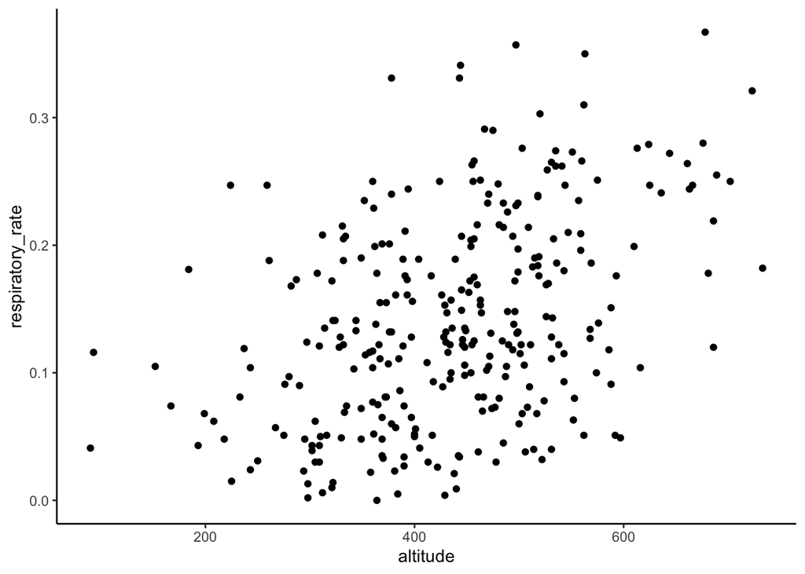

```r
### figure to check linearity goes here.
### no need for fancy, can keep labels as is, etc.
#make a plot to make sure the assumptions are met. In this case, we are looking to see if there is a linear relationship. Is it a predictor? Altitude is a numeric predictor. Response goes on the y
ggplot(rowan, aes(x = altitude , y = respiratory_rate)) +
  geom_point() #looks like not a great linear relationship. Appears that the residuals will be very high. It is reasonable to still do a linear line
```

Now that you have confirmed the relationship is linear (hint: it is linear), build your linear model. *BEFORE you examine its output*, evaluate whether the model residuals were normally distributed:

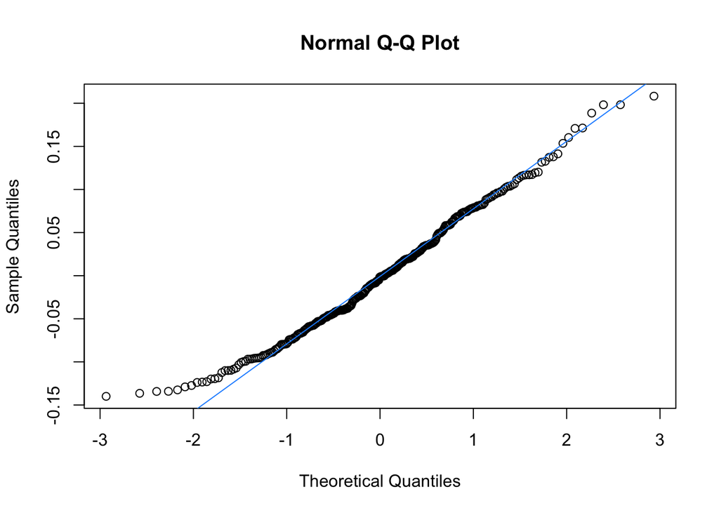

```r
### build model and check normal residuals
### do not look at the model summary yet!
#MUST BE Y~X
lm(respiratory_rate ~ altitude, data = rowan) -> fit #need to look at residuals. This is a linear model!

#get residuals
broom::augment(fit, rowan) -> aug_fit #give it the model and then the data. We defined fit above and rowan is the data set! Augment is the function that gets the residuals

#21 is an open closed circle instead of closed circle. 19 is closed circle. pch defines which shape type you choose.
qqnorm(aug_fit$.resid, pch = 21)
qqline(aug_fit$.resid, col = "dodgerblue") #together these make a qq plot. Why don't you need to have a plus sign like in ggplot? How does it know these are together?
```

Now that you have confirmed the residuals are roughly normally distributed (hint: they are), examine the output from your linear model. In the space below the code chunk, discuss in *bullet form* (1-2 sentences each): a) Provide an interpretation of the intercept, b) Provide an interpretation of the altitude coefficient, c) Provide an interpretation of the $R^2$ value (those dollar signs signify “math mode” - see the HTML output!), and finally d) Conclude whether altitude is a strong or weak predictor of respiratory rate, consider “biological significance” (effect size!) as well as statistical significance.

```r
## examine model output here
summary(fit)
```

```
##
## Call:
## lm(formula = respiratory_rate ~ altitude, data = rowan)
##
## Residuals:
##      Min       1Q   Median       3Q      Max
## -0.13997 -0.05365 -0.00145  0.05206  0.20827
##
## Coefficients:
##              Estimate Std. Error t value Pr(>|t|)
## (Intercept) 8.386e-03  1.702e-02   0.493    0.622
## altitude    3.025e-04  3.778e-05   8.007 2.66e-14 ***
## ---
## Signif. codes:  0 '***' 0.001 '**' 0.01 '*' 0.05 '.' 0.1 ' ' 1
##
## Residual standard error: 0.07333 on 298 degrees of freedom
## Multiple R-squared:  0.177,  Adjusted R-squared:  0.1743
## F-statistic: 64.11 on 1 and 298 DF,  p-value: 2.66e-14
```

- **Intercept interpretation:** When altitude is zero, the respiratory rate is $8.386 \times 10^{-3}$. This makes sense biologically because you can be at an altitude of zero. This is considered sea level. However, since the p value is at 0.622, there is no evidence that the intercept differs from 0. A p value is significant at 0.05 or less. Therefore, the intercept is not significant.
- **Altitude coefficient interpretation:** For every unit increase in altitude, we expect the respiratory rate to increase by $3.025 \times 10^{-4}$. This is highly significant because the p value is $2.66 \times 10^{-14}$. We can then reject the null that the coefficient is 0.
- **$R^2$ interpretation:** We are using the adjusted $R^2$ which is 0.1743. This tells us that 17.43% of variation in respiratory rate is explained by this model, which is included only with altitude as the predictor. This is highly significant at $2.66\times 10^{-14}$. Additionally, this means that 82.57% of variation in respiratory rate is unexplained by the model.
- **Model conclusion:** This would be considered a signficiant model but it has weak explanatory power. There is a lot of error and much of the data *cannot* be explained by the model. We are sure that the $R^2$ is *not* zero but it is not *very* far from zero so this means that it has a weak explanatory power.

This is the equation of the line: y + 3.025e-0.4x + 8.386e-03 We should look at how small the number this is based on the scale of the data. Order of magnitude defines an order of 10. X is altitude.

Finally, make a stylish scatterplot of your findings. Your scatterplot should:

- Use your favorite ggplot theme and colors (it’s allowed to like the default!)
- Clearly show the regression line and its 95% confidence interval
- Include a meaningful title, along with a subtitle that is the fitted model itself, as well as other nice labels
- Include a well-placed annotation that gives the model’s $R^2$

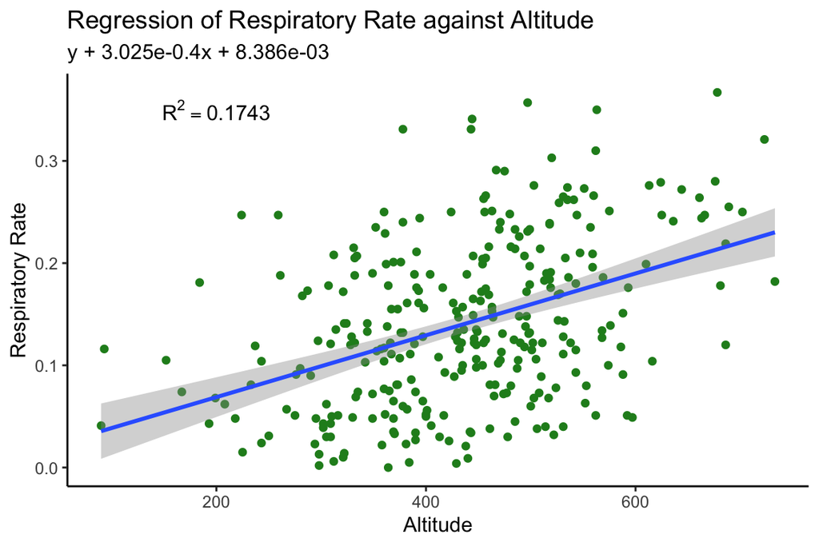

```r
### stylish plot goes here
ggplot(rowan, aes(x = altitude , y = respiratory_rate)) +
  geom_point(color = "forestgreen") +
  labs(title = "Regression of Respiratory Rate against Altitude",
       subtitle = "y + 3.025e-0.4x + 8.386e-03") +
  geom_smooth(method = "lm") + #less data by the top and bottom. Default confidence interval is 95%.
  annotate("text",
           y = 0.35,
           x = 200,
           label = "R^2 == 0.1743",
           parse = T) +
  labs(x = "Altitude",
       y = "Respiratory Rate")
```

### Question 2

> Background for this completing question is under the header “Simple ANOVA: Single categorical predictor” in the linear regression tutorial

Construct a linear model that examines how *species* might explain variation in *respiratory rate*. Take the following steps to do so (code as you go through the steps!)

Make a quick plot (use `geom_point()`, seriously, not even a jitter!!) to make sure the “equal variance” assumption is met for this data:

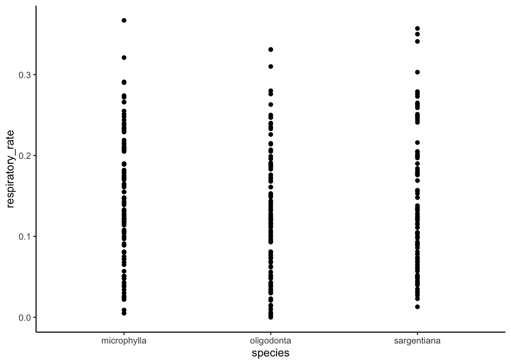

```r
### figure to check assumption goes here.
### no need for fancy, can keep labels as is, etc.
#all anovas are linear regressions but with categorical predictor
#the assumption that we need to check. We need equal variance.
ggplot(rowan, aes(x = species, y = respiratory_rate)) +
  geom_point() #this shows equal variance. The spread is all about the same. The assumption is met and now we are good. Although, it is important to note that we did not REQUIRE them to be all the same. The fact that they are all the same is likely that they are not different from each other. We are just trying to see if the spread is the same (ie. variation). We are able to confirm spread using a geom_point scatterplot! Also, when we say that we want to see how species might explain variation in respiratory rate, we are saying that species is the x and respiratory rate is the y!
```

Now that you have confirmed the variance is equal across groups (hint: it is), build your linear model. *BEFORE you examine its output*, evaluate whether the model residuals were normally distributed:

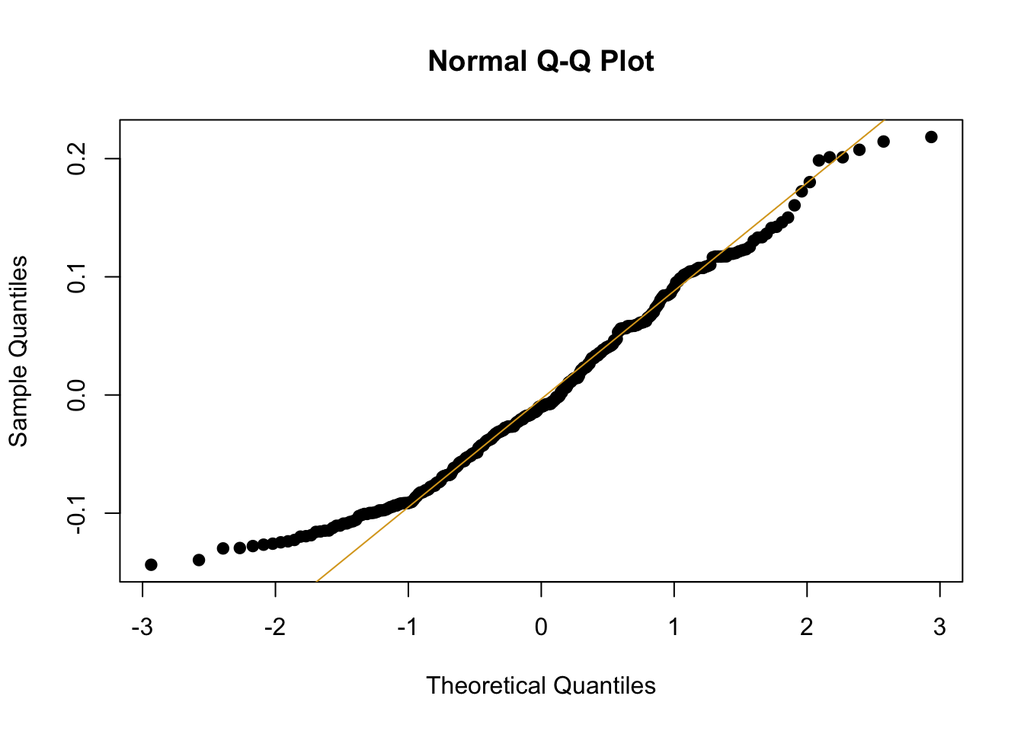

```r
### build model and check normal residuals
### do not look at the model summary yet!
lm(respiratory_rate ~ species, data = rowan) -> fit2 #need to look at residuals

#get residuals
broom::augment(fit2, rowan) -> aug_fit2 #give it the model and then the data
#21 is an open circle instead of closed circle. 19 is a closed circle.
qqnorm(aug_fit2$.resid, pch = 19)
qqline(aug_fit2$.resid, col = "goldenrod")
```

```r
#need the augment model with the dollar sign and .resid to get the residuals. They are rougly normal here. The tails swing out a but at the end but not too much that we cannot consider it normal!
```

Now that you have confirmed the residuals are roughly normally distributed (hint: they are), examine the output from your linear model. In the space below the code chunk, discuss in *bullet form* (1-2 sentences each): a) Provide an interpretation of the intercept, b) Provide an interpretation of the species coefficient, c) Provide an interpretation of the $R^2$ value, and finally d) Conclude whether species is a strong or weak predictor of respiratory rate, consider “biological significance” (effect size!) as well as statistical significance.

```r
## examine model output here
summary(fit2)
```

```
##
## Call:
## lm(formula = respiratory_rate ~ species, data = rowan)
##
## Residuals:
##       Min        1Q    Median        3Q       Max
## -0.143680 -0.065087 -0.009765  0.058320  0.218320
##
## Coefficients:
##                     Estimate Std. Error t value Pr(>|t|)
## (Intercept)         0.148680   0.008059  18.450   <2e-16 ***
## speciesoligodonta  -0.018830   0.011397  -1.652   0.0995 .
## speciessargentiana -0.006180   0.011397  -0.542   0.5880
## ---
## Signif. codes:  0 '***' 0.001 '**' 0.01 '*' 0.05 '.' 0.1 ' ' 1
##
## Residual standard error: 0.08059 on 297 degrees of freedom
## Multiple R-squared:  0.009463,   Adjusted R-squared:  0.002792
## F-statistic: 1.419 on 2 and 297 DF,  p-value: 0.2437
```

```r
#rowan %>% (species(level))
#unique(rowan#species) #not a factor so it assumes alphabetical order. We know it's microphylla because it is the only one that has a coefficient
```

- **Intercept interpretation:** For microphylla trees, we expect a mean of respiratory rate of 0.148680 when microphylla is zero. We can tell that this is highly significant since there is a p value is $2 \times 10^{-16}$. This means that the intercept is definitely not zero. However, the intercept does not make biological sense because a species is never zero. The model fit chooses alphabetically what is the baseline; in this case, it is microphilia. For all categorical data, the intercept is relative to the baseline.
- **Species coefficient interpretation:** There are two species coefficient. They tell you what each one is relative to the baseline which, again, is microphylla.
  - For the first one, we expect, on average, that oligodonta trees have a respiratory rate 0.018830 lower than microphylla. It is compared to the microphylla as the baseline. However, this is *not* significant with a p value of 0.0995, so there is no evidence that it differs from zero.
  - For the second one, we expect, sargentiana trees have a respiratory rate 0.006180 lower than microphylla. However, again, this is *not* significantly different with a p value of 0.5880.
- **$R^2$ interpretation:** $R^2$ = 0.002792 which is not significant with a p value of 0.2437. This tells us that the model explains only 0.2792% of the data. 99.7208% of the data is unexplained!
- **Model conclusion:** The model has no explanatory evidence which means this is an entirely uninformative model.

Finally, make a stylish figure of your findings, choosing your own geom!

- Use your favorite ggplot theme and colors (it’s allowed to like the default!)
- If your geom does not already show the center of each group (i.e. like a boxplot), be sure to add the means in with `stat_summary()`
- Include a meaningful title, along with a subtitle that is the fitted model itself, as well as other nice labels
- Include a well-placed annotation that gives the model’s $R^2$

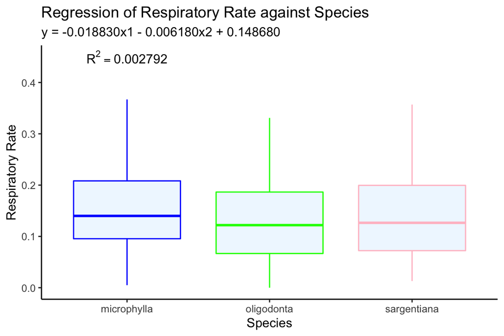

```r
### stylish plot goes here
ggplot(rowan, aes(x = species, y = respiratory_rate))+
  geom_boxplot(color = c("blue", "green", "pink"), fill = "aliceblue") +
  labs(title = "Regression of Respiratory Rate against Species",
       subtitle = "y = -0.018830x1 - 0.006180x2 + 0.148680") +
  geom_smooth(method = "lm") + #less data by the top and bottom. Default confidence interval is 95%.
  annotate("text",
           y = 0.45,
           x = 1,
           label = "R^2 == 0.002792",
           parse = T) +
  labs(x = "Species",
       y = "Respiratory Rate")
```

```r
##another way to do this. If you cannot see the standard error, it means it is small
#ggplot(rowan, aes(x = species, y = respiratory_rate))+
  #geom_jitter(width = 0.15) +
  #stat_summary(color = "hotpink") defaults to mean and standard error
```

### Question 3

> Background for this completing question is under the header “LM with numeric and categorical predictors” in the linear regression tutorial

Construct a linear model that examines how BOTH *species* and *leaf_len* as independent effects might explain variation in *respiratory rate*. Again, take the following steps one by one:

Since we already checked assumptions for `species` in the last question, make an appropriate plot to check the linearity assumption for `leaf_len`:

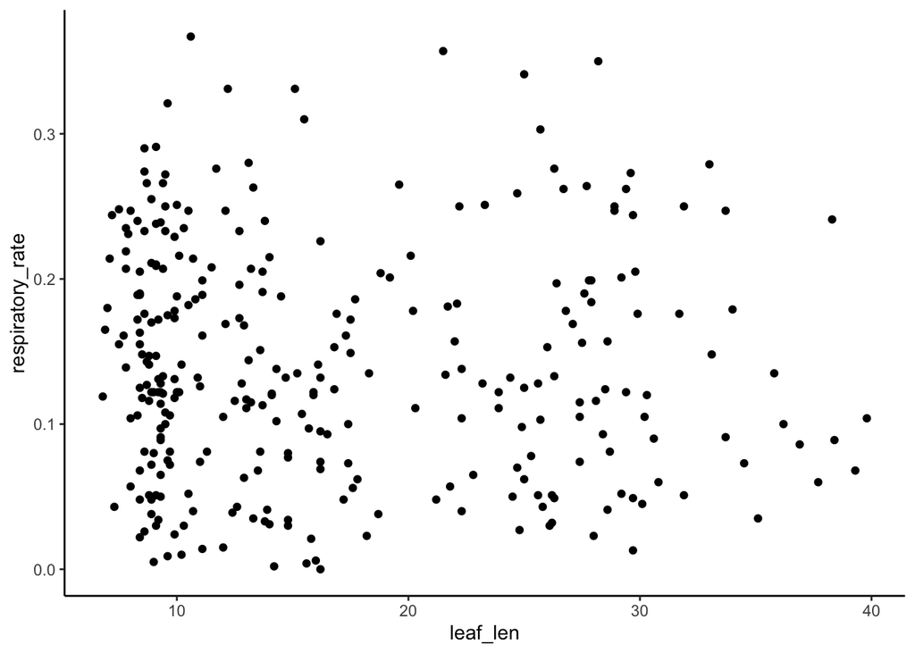

```r
### figure to check assumption goes here.
### no need for fancy, can keep labels as is, etc.
ggplot(rowan, aes(x = leaf_len, y = respiratory_rate)) +
  geom_point() #not a curve so need linear regression
```

Build your linear model, and evaluate whether the model residuals were normally distributed:

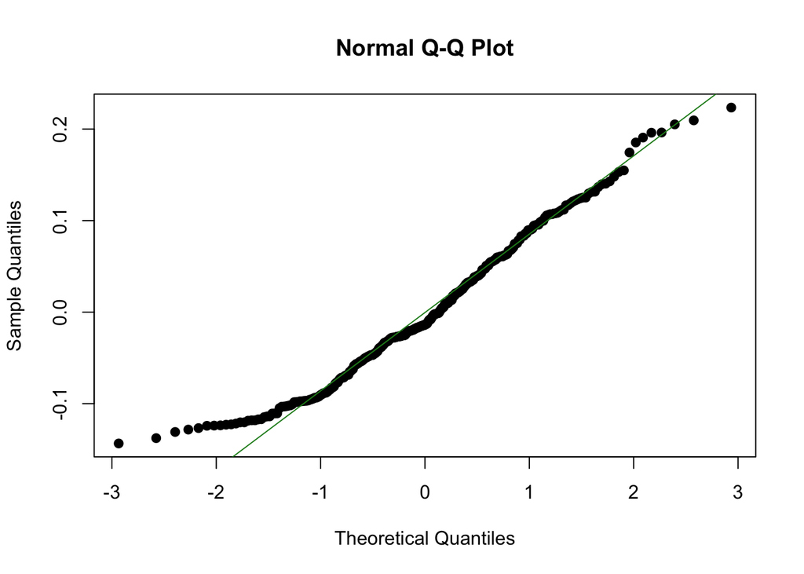

```r
### build model and check normal residuals
### do not look at the model summary yet!
fit3 <- lm(respiratory_rate ~ species + leaf_len, data = rowan)
broom::augment(fit3, rowan) -> aug_fit3 #give it the model and then the data
#21 is closed circle instead of closed circle
qqnorm(aug_fit3$.resid, pch = 19)
qqline(aug_fit3$.resid, col = "forestgreen")
```

Now that you have confirmed the residuals are roughly normally distributed (hint: they are), examine the output from your linear model. In the space below the code chunk, discuss in *bullet form* (1-2 sentences each): a) Provide an interpretation of the intercept, b) Provide an interpretation of the `species` coefficient, c) Provide an interpretation of the `leaf_len` coefficient d) Provide an interpretation of the $R^2$ value, and finally e) Conclude whether species is a strong or weak predictor of respiratory rate, consider “biological significance” (effect size!) as well as statistical significance.

```r
## examine model output here
summary(fit3)
```

```
##
## Call:
## lm(formula = respiratory_rate ~ species + leaf_len, data = rowan)
##
## Residuals:
##      Min       1Q   Median       3Q      Max
## -0.14344 -0.05814 -0.01373  0.05732  0.22345
##
## Coefficients:
##                     Estimate Std. Error t value Pr(>|t|)
## (Intercept)         0.175923   0.015300  11.498   <2e-16 ***
## speciesoligodonta  -0.003898   0.013396  -0.291   0.7713
## speciessargentiana  0.050740   0.029495   1.720   0.0864 .
## leaf_len           -0.003054   0.001461  -2.090   0.0375 *
## ---
## Signif. codes:  0 '***' 0.001 '**' 0.01 '*' 0.05 '.' 0.1 ' ' 1
##
## Residual standard error: 0.08013 on 296 degrees of freedom
## Multiple R-squared:  0.02387,    Adjusted R-squared:  0.01398
## F-statistic: 2.413 on 3 and 296 DF,  p-value: 0.06687
```

- **Intercept interpretation:** For a microphylla tree, which is our baseline species again, that has a leaf length of zero, we expect the respiratory rate of 0.175923. It is highly significant because the p value is $2 \times 10^{-16}$. However, this does not make any biological sense. We cannot have a species at zero.
- **Species coefficient interpretation:**
  - When controlling for leaf length, the coefficients are the change from the baseline species.
    - Controlling for leaf length, oligodonta species has an average respiratory rate of 0.003898 lower than microphylla. But it is not signifcant with a p value of 0.7713. Effectively, this means that it is not different from microphylla.
    - Controlling for leaf length, sargentiana has an overage respiratory rate of 0.050740 higher than microphylla. Again, this is not significant because the p value is 0.0864.
- **Leaf length coefficient interpretation:** When controllling for species, the leaf length is 0.003054 less than the base line of microphylla. This is significant with a p value of 0.0375.
- **$R^2$ interpretation:** The $R^2$ value is 0.01398. This means that this model can explain 1.398% of the data. 98.602% of the data is unexplained by this model. Additionally, our p value is 0.06687 which shows that our $R^2$ value is *not* significant.
- **Model conclusion:** Effectively, the explanatory power of this model is zero which means that it is not an informative model.

Finally, make a stylish scatterplot of your findings:

- Use your favorite ggplot theme and colors (it’s allowed to like the default!)
- Make sure to show a regression lines for EACH species. **NOTICE in theses lines** how they are consistent with your conclusions about species being a significant predictor. You do not have to write anything, just notice!
- Include a meaningful title, along with a subtitle that is the fitted model itself, as well as other nice labels
- Include a well-placed annotation that gives the model’s $R^2$

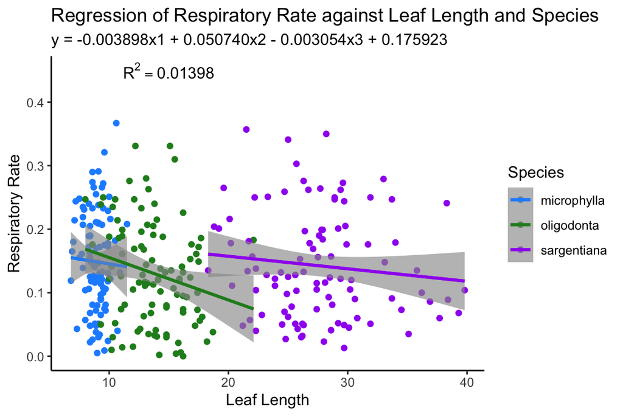

```r
### stylish plot goes here
ggplot(rowan, aes(x = leaf_len, y = respiratory_rate, color = species)) +
  geom_point() +
  geom_smooth(method = "lm") + #there is a strong relationship from leaf length and species. slopes all overlap which is why it is not significant. confidence intervals are overlapping in the y axis. same consistent trend for species.
  labs(title = "Regression of Respiratory Rate against Leaf Length and Species",
       subtitle = "y = -0.003898x1 + 0.050740x2 - 0.003054x3 + 0.175923") +
  geom_smooth(method = "lm") + #less data by the top and bottom. Default confidence interval is 95%.
  annotate("text",
           y = 0.45,
           x = 15,
           label = "R^2 == 0.01398",
           parse = T) +
  labs(x = "Leaf Length",
       y = "Respiratory Rate",
       color = "Species") +
  scale_color_manual(values = c("dodgerblue", "forestgreen", "purple"))
```